# Experiment 1: Airline Data Analysis

2023-09-06

Alexis Alexander

We are loosely following Chapter 4 of R for Data Science and working with the nycflights dataset. Follow this link to the chapter: https://r4ds.hadley.nz/data-transform

Make sure that the following packages are install: 1. nycflights13 2. tidyverse 3. here

Here we are loading the nycflight data and looking inside the data. We want to set df1 to to data for all flights.

```r
library(nycflights13)
library(tidyverse)
library(here)
 df1 = (flights)
 glimpse(flights)
```

```
Rows: 336,776
Columns: 19
$ year           <int> 2013, 2013, 2013, 2013, 2013, 2013, 2013, 201…
$ month          <int> 1, 1, 1, 1, 1, 1, 1, 1, 1, 1, 1, 1, 1, 1, 1, …
$ day            <int> 1, 1, 1, 1, 1, 1, 1, 1, 1, 1, 1, 1, 1, 1, 1, …
$ dep_time       <int> 517, 533, 542, 544, 554, 554, 555, 557, 557, …
$ sched_dep_time <int> 515, 529, 540, 545, 600, 558, 600, 600, 600, …
$ dep_delay      <dbl> 2, 4, 2, -1, -6, -4, -5, -3, -3, -2, -2, -2, …
$ arr_time       <int> 830, 850, 923, 1004, 812, 740, 913, 709, 838,…
$ sched_arr_time <int> 819, 830, 850, 1022, 837, 728, 854, 723, 846,…
$ arr_delay      <dbl> 11, 20, 33, -18, -25, 12, 19, -14, -8, 8, -2,…
$ carrier        <chr> "UA", "UA", "AA", "B6", "DL", "UA", "B6", "EV…
$ flight         <int> 1545, 1714, 1141, 725, 461, 1696, 507, 5708, …
$ tailnum        <chr> "N14228", "N24211", "N619AA", "N804JB", "N668…
$ origin         <chr> "EWR", "LGA", "JFK", "JFK", "LGA", "EWR", "EW…
$ dest           <chr> "IAH", "IAH", "MIA", "BQN", "ATL", "ORD", "FL…
$ air_time       <dbl> 227, 227, 160, 183, 116, 150, 158, 53, 140, 1…
$ distance       <dbl> 1400, 1416, 1089, 1576, 762, 719, 1065, 229, …
$ hour           <dbl> 5, 5, 5, 5, 6, 5, 6, 6, 6, 6, 6, 6, 6, 6, 6, …
$ minute         <dbl> 15, 29, 40, 45, 0, 58, 0, 0, 0, 0, 0, 0, 0, 0…
$ time_hour      <dttm> 2013-01-01 05:00:00, 2013-01-01 05:00:00, 20…
```

We want to set df2 to all flights from Miami in September.

```r
df2 = df1|> filter (month == 9, origin == "MIA")
```

Next, we want to set df3 to all flights in September going to Miami.

```r
 df3 = df1|>
  filter(month==9,dest == "MIA")
```

Next, we want df4 to be equal to flights in January going to Miami.

```r
df4 = df1|>
  filter(month==1,dest == "MIA")
```

Now, we want df5 to be all flights in summer going to Chicago.

```r
df5 = df1|> filter(between(month,06,08), dest == "ORD")
```

Next, we are finding the unique flight numbers for flights to Miami in September.

```r
df_flight_num=df3 |>
  distinct(flight) |>
  arrange(flight)
```

We are pulling up a table to look at a list of the unique flight numbers.

```r
head(df_flight_num)
```

| flight |
| --- |
| 83 |
| 145 |
| 172 |
| 446 |
| 476 |
| 577 |

```r
df6=df1%>% filter(flight==83)
```

We created a visualization (using ggplot) to show the DELAYS associated with the lowest flight number (83).

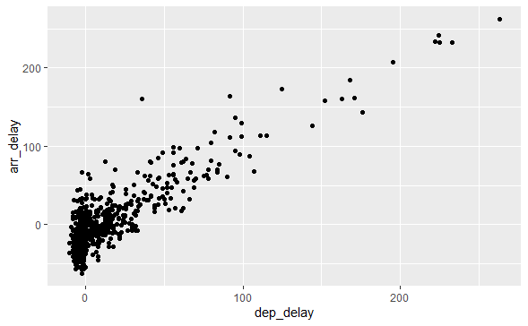

```r
df6 |>
  ggplot(aes(x=dep_delay, y = arr_delay))+geom_point()
```

By looking at the plot created, we noticed that some of the data was removed from the visual due to missing values. In addition, we saw that some of the flight data were negative meaning that some flights had a early departure.

Here we are looking into the df6 data.

```r
view(df6)
```

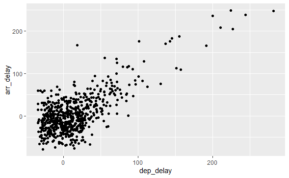

```r
df6 |>
  ggplot(aes(x = dep_delay, y = arr_delay)) +
  geom_jitter(width = 30, height = 30)
```

An observation that we would like to explore more is what is the difference between flights that fall into ranges of (-dep_delay,-arr_delay) and points with coordinates of (-dep_delay, arr_delay) or vice versa? Why does the majority of the flight data fall into the negative range? Are flights that are exactly on time fall on the (0,0) position?

Extra credit: We assumed that a negative value for departure delay representaed an “early departure.” To verify this assumption, we found a source that confirms this: https://www.sciencedirect.com/science/article/pii/S2046043022000119

Citation:

Article Title: Flight delay causality: Machine learning technique in conjunction with random parameter statistical analysis Authors: Seyedmirsajad Mokhtarimousavi, Armin Mehrabi International Journal of Transportation Science and Technology, Volume 12, Issue 1, 2023, Pages 230-244, ISSN 2046-0430, doi:https://doi.org/10.1016/j.ijtst.2022.01.007

In particular the literature states, “Depature delay is the difference between scheduled and actual depature times in minutes in which the early depatures were shown in negative numbers in the dataset and considered to be an early depature.”